# EFleming DACSS 603 HW II

The following document contains my work for DACSS 603 HW II.

EFleming (UMASS Amherst)  
2022-03-08

## Question 1

(Problem 1.1 in ALR)

United Nations (Data file: UN11) The data in the file UN11 contains several variables, including ppgdp, the gross national product per person in U.S. dollars, and fertility, the birth rate per 1000 females, both from the year 2009. The data are for 199 localities, mostly UN member countries, but also other areas such as Hong Kong that are not independent countries. The data were collected from the United Nations (2011). We will study the dependence of fertility on ppgdp.

1.1.1. Identify the predictor and the response.

### Answer

**The predictor is ppgdp and the response is fertility. Fertility depends on ppgdp.** This question is a bit tricky and had me confused at first as it is easy to make the mistake of making fertility the predictor influencing “y.” However, based on my logic, I would argue it is the inverse as my answer states.

1.1.2 Draw the scatterplot of fertility on the vertical axis versus ppgdp on the horizontal axis and summarize the information in this graph. Does a straight-line mean function seem to be plausible for a summary of this graph?

### Answer

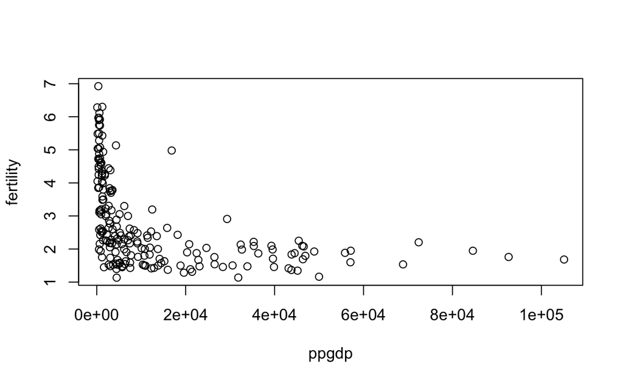

```r
attach(UN11)
plot(fertility~ppgdp, data=UN11)
```

*The relationship does not seem linear. There is an inverse and therefore negative relationship. A straight line function would not be plausible in this case. We cannot draw a solid straight line without making changes to the variables themselves as we can with logs (which we will use next).

1.1.3 Draw the scatterplot of log(fertility) versus log(ppgdp) using natural logarithms. Does the simple linear regression model seem plausible for a summary of this graph? If you use a different base of logarithms, the shape of the graph won’t change, but the values on the axes will change.

### Answer

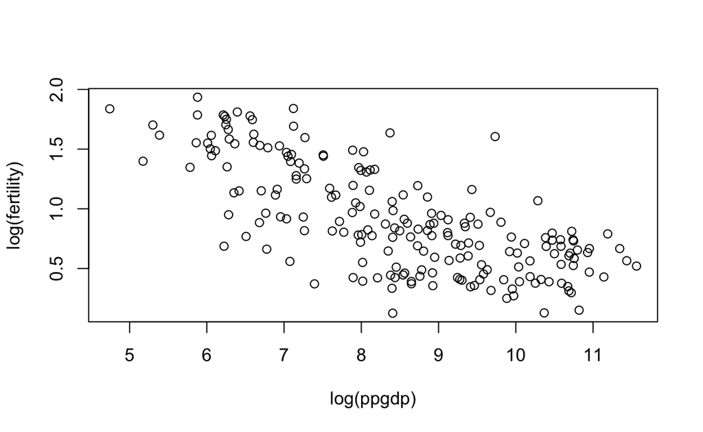

```r
attach(UN11)
plot(log(fertility)~log(ppgdp), data=UN11)
```

*Yes, the log transformation created two variables that are linearly related. The log helps create a better fit for our data. With the logs, we transform the variables. The line generated using the lines is much better and more smooth when we implement the logs. The log transformation creates two variables that are linearly related. We can use simple linear regression to estimate the effect of log(ppgdp on log(fertility).

## Question 2

Annual income, in dollars, is an explanatory variable in a regression analysis. For a British version of the report on the analysis, all responses are converted to British pounds sterling (1 pound equals about 1.33 dollars, as of 2016).

1. How, if at all, does the slope of the prediction equation change?

### Answer

We want to take the income in dollars and make it pounds. In other words $1330 = 1.33 x 1000 for example. I

y= B0 + B1 Inc($) + E y= B0 + B1(Inc(pounds x 1.33)) + E

Therefore it can be written as: y= B0 + 1.33B1Inc(pounds) + E ^^^We get a new slope which is 1.33 times the old slope

2. How, if at all, does the correlation change?

### Answer

The correlation does not change at all.

## Question 3

Water runoff in the Sierras (Data file: water) Can Southern California’s water supply in future years be predicted from past data? One factor affecting water availability is stream runoff. If runoff could be predicted, engineers, planners, and policy makers could do their jobs more efficiently. The data file contains 43 years’ worth of precipitation measurements taken at six sites in the Sierra Nevada mountains (labeled APMAM, APSAB, APSLAKE, OPBPC, OPRC, and OPSLAKE) and stream runoff volume at a site near Bishop, California, labeled BSAAM. Draw the scatterplot matrix for these data and summarize the information available from these plots.

We want to see how correlated each of the sites are to one another in order to see if this can help us predict Steam Runoff.

### Answer

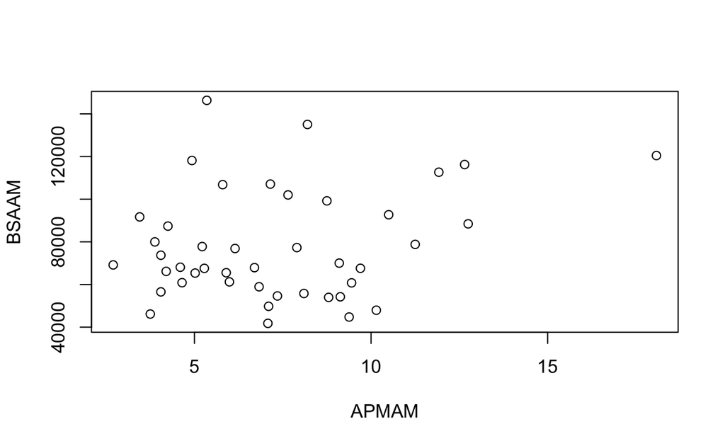

```r
plot(BSAAM~APMAM, data = water)
```

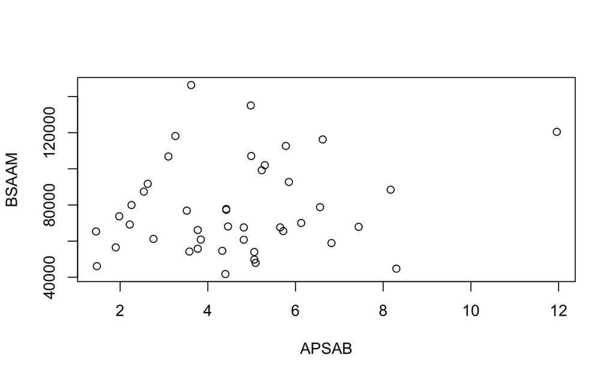

```r
plot(BSAAM~APSAB,data = water)
```

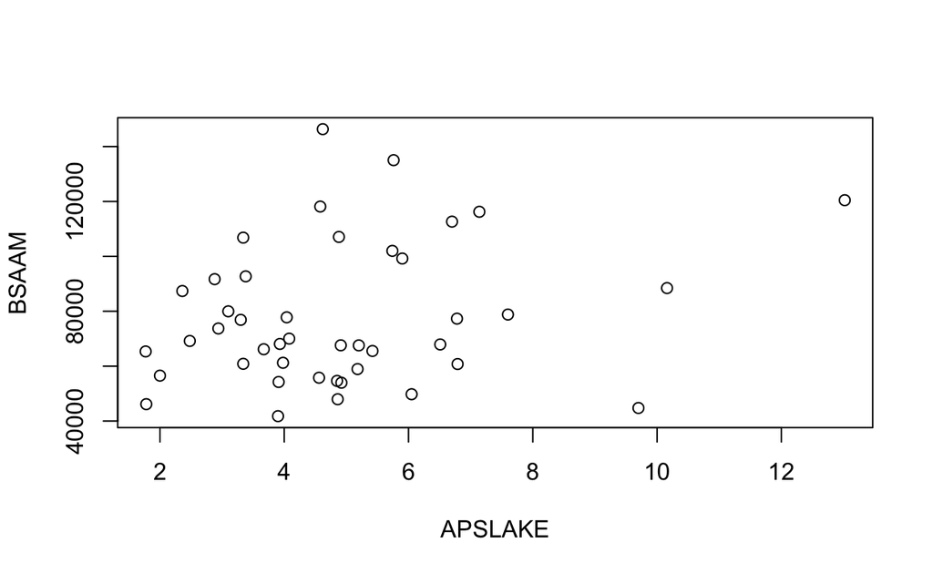

```r
plot(BSAAM~APSLAKE,data = water)
```

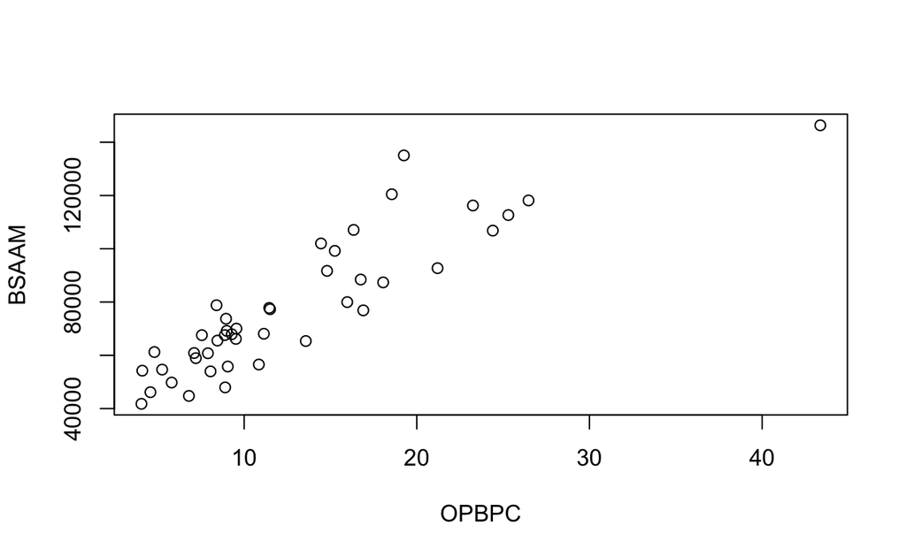

```r
plot(BSAAM~OPBPC, data = water)
```

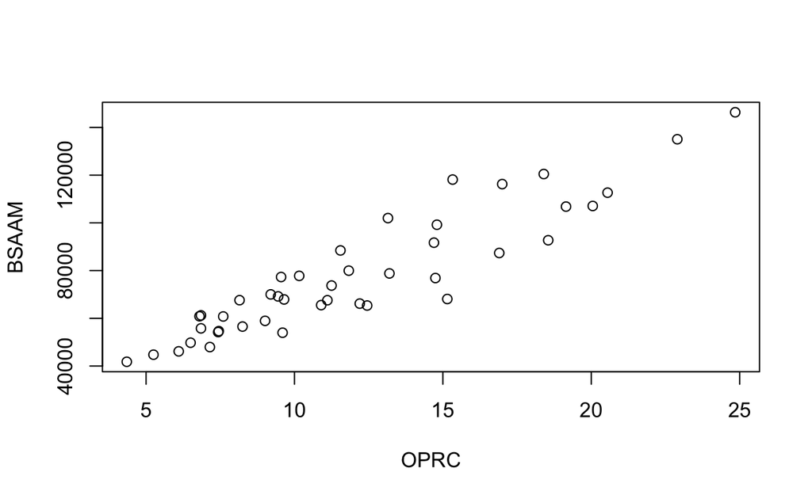

```r
plot(BSAAM~OPRC, data = water)
```

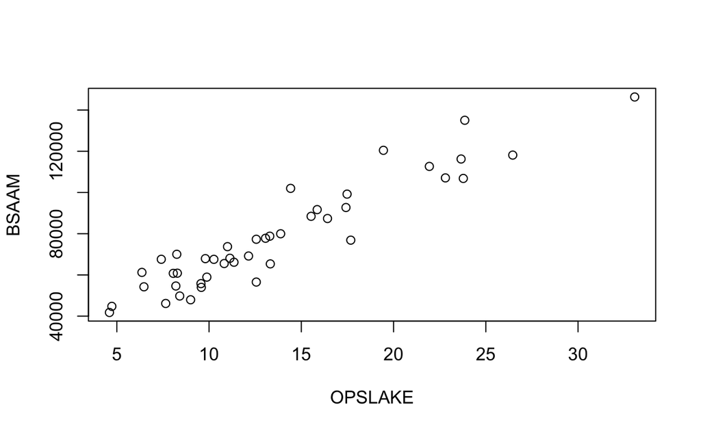

```r
plot(BSAAM~OPSLAKE, data = water)
```

There is a relatively strong and positive linear relationship between stream run off and precipitation measures taken at “OPBPC,” “OPRC,” and “OPSLake.” There is no relationship between the others. Here we are running a bi-variate comparison for BSAAM–as this particular site helps us determine runoff when used in conjunction with other individual sites.

## Question 4

Professor ratings (Data file: Rateprof) In the website and online forum RateMyProfessors.com, students rate and comment on their instructors. Launched in 1999, the site includes millions of ratings on thousands of instructors. The data file includes the summaries of the ratings of 364 instructors at a large campus in the Midwest (Bleske-Rechek and Fritsch, 2011). Each instructor included in the data had at least 10 ratings over a several year period. Students provided ratings of 1–5 on quality, helpfulness, clarity, easiness of instructor’s courses, and raterInterest in the subject matter covered in the instructor’s courses. The data file provides the averages of these five ratings. Use R to reproduce the scatterplot matrix in Figure 1.13 in the ALR book (page 20). Provide a brief description of the relationships between the five ratings. (The variables don’t have to be in the same order)

### Answer

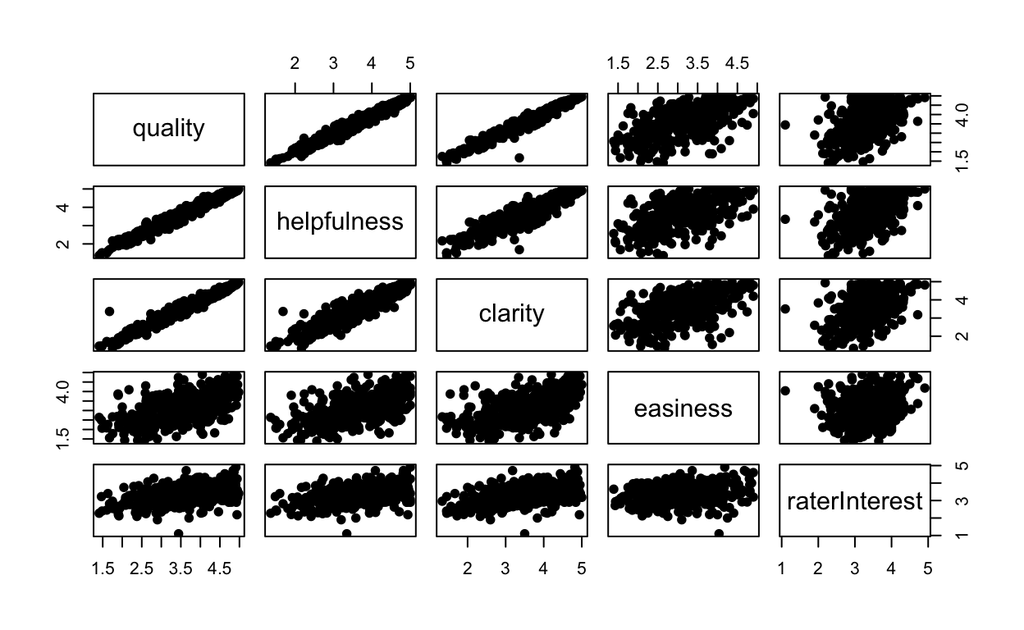

```r
data("Rateprof")
pairs(Rateprof[,8:12], pch=19)
```

“Quality~Helpfulness,” “Quality~Clarity” and “Helpfulness~Clarity” paris have strong positive correlations and all other pairs have a small positive correlation except (“raterInterest” ~ “Easiness”) which seems to have almost zero correlation. Here, we use the pairs() function to compare the correlation between variables in a bi-variate manner without having to incorporate multiple linear regression (which can get a bit messy very quickly with too many variables). We can recreate the nice table given to us in the text book very simply by using the code above.

## Question 5

For the student.survey data file in the smss package, conduct regression analyses relating (i) y = political ideology and x = religiosity, (ii) y = high school GPA and x = hours of TV watching.

(You can use ?student.survey in the R console, after loading the package, to see what each variable means.)

### (a) Use graphical ways to portray the individual variables and their relationship.

### Answer (i)

For the correlation between political ideology and religiosity, we use the xtabs() function which allows us to compare the relationship between 2 categorical variables.

```r
data("student.survey")
xtabs(~re + pi, student.survey)
```

```
              pi
re             very liberal liberal slightly liberal moderate
  never                   3       8                2        1
  occasionally            5      14                1        8
  most weeks              0       1                1        1
  every week              0       1                2        0
              pi
re             slightly conservative conservative very conservative
  never                            1            0                 0
  occasionally                     1            0                 0
  most weeks                       2            2                 0
  every week                       2            2                 2
```

```r
cor.test(as.numeric(student.survey$re), as.numeric(student.survey$pi))
```

```
    Pearson's product-moment correlation

data:  as.numeric(student.survey$re) and as.numeric(student.survey$pi)
t = 5.4163, df = 58, p-value = 1.221e-06
alternative hypothesis: true correlation is not equal to 0
95 percent confidence interval:
 0.3818345 0.7265650
sample estimates:
      cor
0.5795661
```

```r
rmean = aggregate(as.numeric(student.survey$re), by = list(student.survey$pi), mean)
```

^^The code above gives average values for religiosity for each political view on the liberal to conservative scale.

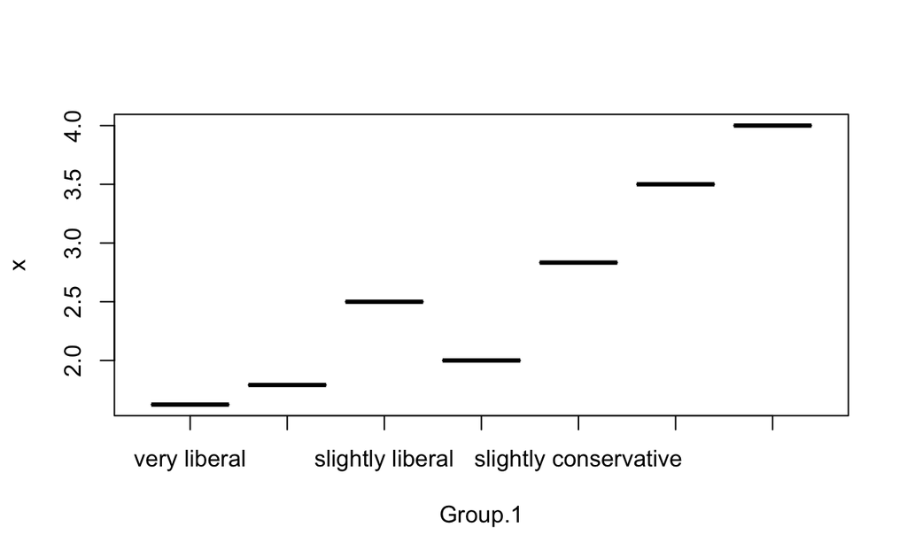

```r
plot(rmean)
```

^^The graphical representation a basic representation of how things look with regards to political ideology and religiosity. If we want to take it a step further, we can use the “error.bar.by” function included in the “psych” package. This plot will be provided below.

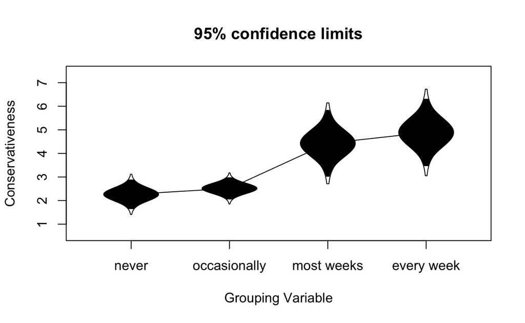

```r
error.bars.by(as.numeric(student.survey$pi),student.survey$re, ylab = "Conservativeness", v.labels=c("never", "occasionally", "most weeks", "every week"))
```

The lines connect the means using this plot. This graphically explains those that attend church more often have higher levels of conservativeness. At the very least, there is a moderate to high correlation.

### Answer (ii)

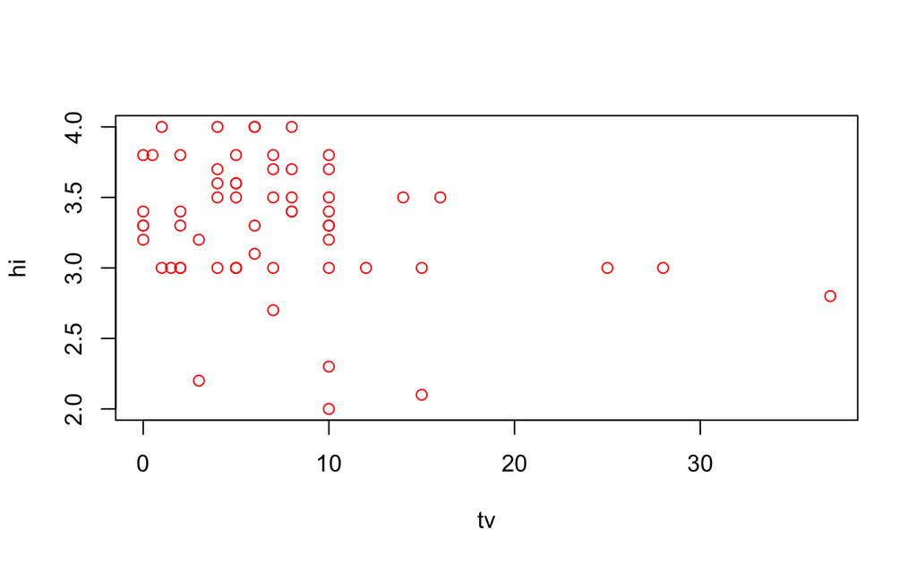

```r
data("student.survey")
plot(~tv + hi, student.survey, col = "red")
```

For the correlation between high school GPA and hours spent watching TV, we use the plot function as both “tv” & “hi” are numerical values making it possible to plot their relationship.

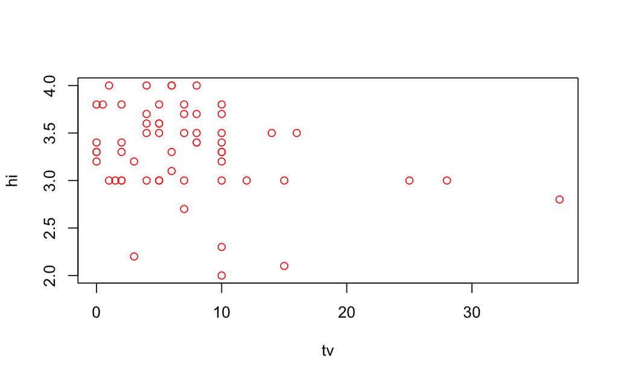

```r
data("student.survey")
plot(~tv + hi, student.survey, col = "red")
```

### (b) Interpret descriptive statistics for summarizing the individual variables and their relationship.

### Answer (i)

Here, we are comparing the political ideology and how often people attend religious services. As we can see, a much larger percentage of people to the left of moderate attend church occasionally or do not attend church at all. Moderates have a very similar relationship with regards to more liberal individuals and their church attending activity. As for conservatives, there is a larger percentage of those that attend church “most week” or “every week.” However, one issue is the fact that at first glance, there are more entries for people that are moderates or liberals than for those that are conservative. Therefore, this somewhat skews the interpretation of the data.

### Answer (ii)

There does appear to be at least somewhat of a correlation between GPA and hours spent watching TV. However, because we cannot draw a smooth line without most likely implementing logs to help smooth things out. Therefore, we cannot say a considerable correlation exists. Instead, we have a weaker negative correlation that exists.

```r
data("student.survey")
lm(tv~hi, data = student.survey)
```

```
Call:
lm(formula = tv ~ hi, data = student.survey)

Coefficients:
(Intercept)           hi
     20.200       -3.909
```

### (c) Summarize and interpret results of inferential analyses.

### Answer (i)

```r
data("student.survey")
xtab = table(student.survey$re, student.survey$pi)
chisq.test(xtab)
```

```
    Pearson's Chi-squared test

data:  xtab
X-squared = 42.288, df = 18, p-value = 0.001008
```

Here, we are able to accept our alternative hypothesis and reject our null hypothesis because the p-value is very small. This means that events are dependent on one another. For two ordinal variables, it is somewhat tricky with regards to testing how correlated to one another they really are. We could technically simply relabel the ordinal data as numerical data (as we did) to compare this data more readily.

### Answer (ii)

```r
data("student.survey")
cor.test(student.survey$tv, student.survey$hi)
```

```
    Pearson's product-moment correlation

data:  student.survey$tv and student.survey$hi
t = -2.1144, df = 58, p-value = 0.03879
alternative hypothesis: true correlation is not equal to 0
95 percent confidence interval:
 -0.48826914 -0.01457694
sample estimates:
       cor
-0.2675115
```

Because these two variables are numerical, we can run a correlation test where Pearson’s is being used by default. Here, we can reject the null hypothesis and accept our alternative hypothesis because the p-value is below .05. Here we have a very weak negative correlation for “r.” This was indicated graphically above. We also have a t-value slightly greater than -2 which gives us more evidence of the correlation being exhibited.

## Question 6

### Answer

Conceptually, correlation does not prove causation! There are a myriad of other factors that could act as confounding variables which could have affected higher scores in the tutored class. This conclusion can quickly fall into the category of *omitted variable bias.* In order to avoid confirmation bias, we should be looking for any other variables that could have possibly had an impact on the class that was tutored. The problem here is that we are not controlling for any of the other factors.